# EuroSAT Land Use Classification

## with ResNet50 Built From Scratch

**Satellite Image Classification using Sentinel-2 Data**

*Built without any pretrained weights — trained from random initialization*

## 1. Configuration

```python
import os
import random
import numpy as np
import torch

# --- Paths ---
# Kaggle
DATA_DIR = "/kaggle/input/datasets/marwanmesbah19/eurosat-rgb-1/EuroSAT_RGB"
# Local:
# DATA_DIR = "../Dataset/EuroSAT_RGB"

OUTPUT_DIR = "/kaggle/working" if os.path.exists("/kaggle/working") else "../outputs"
os.makedirs(OUTPUT_DIR, exist_ok=True)

# --- Hyperparameters ---
BATCH_SIZE = 64
NUM_EPOCHS = 100
LEARNING_RATE = 3e-4
WEIGHT_DECAY = 1e-4
NUM_CLASSES = 10
SEED = 42
TRAIN_SPLIT = 0.70
VAL_SPLIT = 0.15
TEST_SPLIT = 0.15
PATIENCE = 8

# --- Device ---
DEVICE = torch.device("cuda" if torch.cuda.is_available() else "cpu")
USE_AMP = DEVICE.type == "cuda"

print(f"Device: {DEVICE}")
print(f"Mixed precision: {USE_AMP}")

# --- Reproducibility ---
def seed_everything(seed):
    random.seed(seed)
    np.random.seed(seed)
    torch.manual_seed(seed)
    torch.cuda.manual_seed_all(seed)
    torch.backends.cudnn.deterministic = False
    torch.backends.cudnn.benchmark = True  # fixed 224x224 input → autotune is safe

seed_everything(SEED)
```

```
Device: cuda
Mixed precision: True
```

## 2. Imports

```python
import copy
import time
import matplotlib.pyplot as plt
import seaborn as sns
import pandas as pd
from tqdm import tqdm

import torch.nn as nn
import torch.optim as optim
import torchvision.transforms as transforms
import torchvision.datasets as datasets
from torch.utils.data import DataLoader, SubsetRandomSampler, WeightedRandomSampler

from sklearn.metrics import (
    accuracy_score,
    classification_report,
    confusion_matrix,
    f1_score,
)

print("All imports successful.")
```

```
All imports successful.
```

## 3. Data Loading and Preprocessing

```python
# ImageNet normalization — wider range helps separate hard classes
IMAGENET_MEAN = [0.485, 0.456, 0.406]
IMAGENET_STD = [0.229, 0.224, 0.225]

print(f"Normalization: ImageNet standard")
print(f"Mean: {IMAGENET_MEAN}")
print(f"Std:  {IMAGENET_STD}")

# Training augmentations — designed for satellite imagery
train_transform = transforms.Compose([
    transforms.Resize(256),
    transforms.RandomResizedCrop(224, scale=(0.8, 1.0)),
    transforms.RandomHorizontalFlip(p=0.5),
    transforms.RandomVerticalFlip(p=0.5),
    transforms.RandomRotation(15),
    transforms.ColorJitter(brightness=0.2, contrast=0.2, saturation=0.1, hue=0.02),
    transforms.ToTensor(),
    transforms.Normalize(mean=IMAGENET_MEAN, std=IMAGENET_STD),
])

# Validation/test transforms — deterministic
val_transform = transforms.Compose([
    transforms.Resize(256),
    transforms.CenterCrop(224),
    transforms.ToTensor(),
    transforms.Normalize(mean=IMAGENET_MEAN, std=IMAGENET_STD),
])
```

```
Normalization: ImageNet standard
Mean: [0.485, 0.456, 0.406]
Std:  [0.229, 0.224, 0.225]
```

```python
# Load dataset and create train/val/test splits
full_dataset = datasets.ImageFolder(root=DATA_DIR)
class_names = full_dataset.classes
dataset_size = len(full_dataset)

print(f"Classes ({len(class_names)}): {class_names}")
print(f"Total images: {dataset_size}")

# Shuffle and split indices
indices = list(range(dataset_size))
np.random.shuffle(indices)

train_end = int(TRAIN_SPLIT * dataset_size)
val_end = train_end + int(VAL_SPLIT * dataset_size)

train_idx = indices[:train_end]
val_idx = indices[train_end:val_end]
test_idx = indices[val_end:]  # remainder → test

print(f"Train: {len(train_idx)} | Val: {len(val_idx)} | Test: {len(test_idx)}")

# Create datasets with appropriate transforms
train_dataset = datasets.ImageFolder(root=DATA_DIR, transform=train_transform)
val_dataset = datasets.ImageFolder(root=DATA_DIR, transform=val_transform)

# --- Data Imbalance Handling ---
# Compute class weights from training set for weighted loss
train_targets = [full_dataset.targets[i] for i in train_idx]
class_counts_train = np.bincount(train_targets)
print(f"Training class counts: {dict(zip(class_names, class_counts_train))}")

# Class weights: inverse frequency, normalized so weights average to 1.0
class_weights = 1.0 / class_counts_train
class_weights = class_weights / class_weights.sum() * len(class_counts_train)
print(f"Class weights: {dict(zip(class_names, class_weights.round(3)))}")

# DataLoaders — using SubsetRandomSampler (standard random sampling)
# Imbalance is handled by weighted loss only (not sampler) to avoid overfitting
train_loader = DataLoader(train_dataset, batch_size=BATCH_SIZE,
                          sampler=SubsetRandomSampler(train_idx),
                          num_workers=2, pin_memory=True)
val_loader = DataLoader(val_dataset, batch_size=BATCH_SIZE,
                        sampler=SubsetRandomSampler(val_idx),
                        num_workers=2, pin_memory=True)
test_loader = DataLoader(val_dataset, batch_size=BATCH_SIZE,
                         sampler=SubsetRandomSampler(test_idx),
                         num_workers=2, pin_memory=True)
```

```
Classes (10): ['AnnualCrop', 'Forest', 'HerbaceousVegetation', 'Highway', 'Industrial', 'Pasture', 'PermanentCrop', 'Residential', 'River', 'SeaLake']
Total images: 27000
Train: 18900 | Val: 4050 | Test: 4050
Training class counts: {'AnnualCrop': np.int64(2101), 'Forest': np.int64(2082), 'HerbaceousVegetation': np.int64(2143), 'Highway': np.int64(1765), 'Industrial': np.int64(1753), 'Pasture': np.int64(1417), 'PermanentCrop': np.int64(1743), 'Residential': np.int64(2114), 'River': np.int64(1697), 'SeaLak…
Class weights: {'AnnualCrop': np.float64(0.884), 'Forest': np.float64(0.893), 'HerbaceousVegetation': np.float64(0.867), 'Highway': np.float64(1.053), 'Industrial': np.float64(1.06), 'Pasture': np.float64(1.311), 'PermanentCrop': np.float64(1.066), 'Residential': np.float64(0.879), 'River': np.float…
```

## About the EuroSAT Dataset

> *"EuroSAT: A Novel Dataset and Deep Learning Benchmark for Land Use and Land Cover Classification"* — Helber et al., 2019
- **Source:** Sentinel-2 satellite (ESA Copernicus program)
- **Spatial resolution:** 10m per pixel (RGB bands)
- **Image size:** 64×64 pixels
- **Spectral bands:** 13 available (we use RGB: bands 4, 3, 2)
- **Total images:** ~27,000 labeled and geo-referenced images
- **10 classes:** AnnualCrop, Forest, HerbaceousVegetation, Highway, Industrial, Pasture, PermanentCrop, Residential, River, SeaLake

**Why this dataset?** Sentinel-2 provides free, global coverage with high revisit frequency — ideal for land use monitoring, urban planning, and environmental analysis.

**Reference benchmark:** The original paper achieved **98.57% accuracy** using a *fine-tuned* (pretrained) ResNet-50. Our goal: match this from scratch.

## Iterative Development: V1 → V4

We went through 4 versions, testing different approaches to improve accuracy:

| Version | Normalization | Loss | Key Change | Test Accuracy | Epochs |
| --- | --- | --- | --- | --- | --- |
| **V1 (Baseline)** | ImageNet | Standard CE | Full pipeline from scratch | **97.65%** | 100 |
| **V2** | ImageNet | Standard CE | Increased patience (8→12) | **97.65%** | 100 |
| **V3** | **Dataset-specific** | Standard CE | Computed EuroSAT mean/std | **97.58%** | 66 |
| **V4** | ImageNet | **Class-weighted CE** | Handles data imbalance | **97.14%** | 39 |

### Key Findings

- **ImageNet normalization worked best** — even though EuroSAT images are satellite (not natural photos), the wider normalization range `[0.485, 0.456, 0.406]` helped the model separate harder classes like PermanentCrop vs AnnualCrop.
- **Dataset-specific normalization slightly hurt** — EuroSAT's computed mean `[0.345, 0.381, 0.409]` is darker with less variation `std [0.201, 0.136, 0.114]`. This compressed the feature space, making it harder for the network to distinguish similar land cover types.
- **Class weighting reduced accuracy** — despite computing inverse frequency weights for minority classes (Pasture: 1.31, Forest: 0.89), the weighted loss caused premature convergence (stopped at epoch 39) with lower final accuracy. The dataset was already balanced enough (2,000–3,000 per class).
- **Lesson learned:** Sometimes simpler is better. The baseline V1 approach achieved the highest accuracy.

## 4. Dataset Visualization

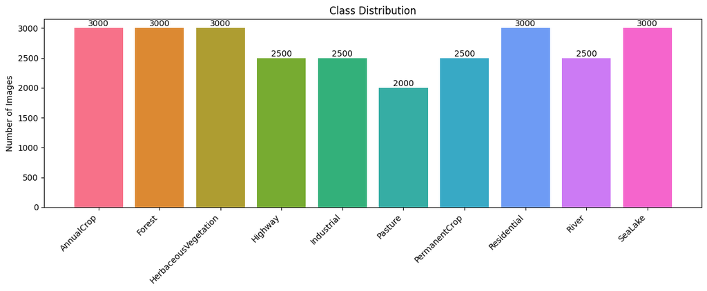

```python
# Class distribution
class_counts = np.bincount(full_dataset.targets)

fig, ax = plt.subplots(figsize=(12, 5))
bars = ax.bar(class_names, class_counts, color=sns.color_palette("husl", len(class_names)))
ax.set_ylabel("Number of Images")
ax.set_title("Class Distribution")
plt.xticks(rotation=45, ha="right")
for bar, count in zip(bars, class_counts):
    ax.text(bar.get_x() + bar.get_width() / 2, bar.get_height() + 30,
            str(count), ha="center", fontsize=10)
plt.tight_layout()
plt.savefig(os.path.join(OUTPUT_DIR, "class_distribution.png"), dpi=150)
plt.show()
```

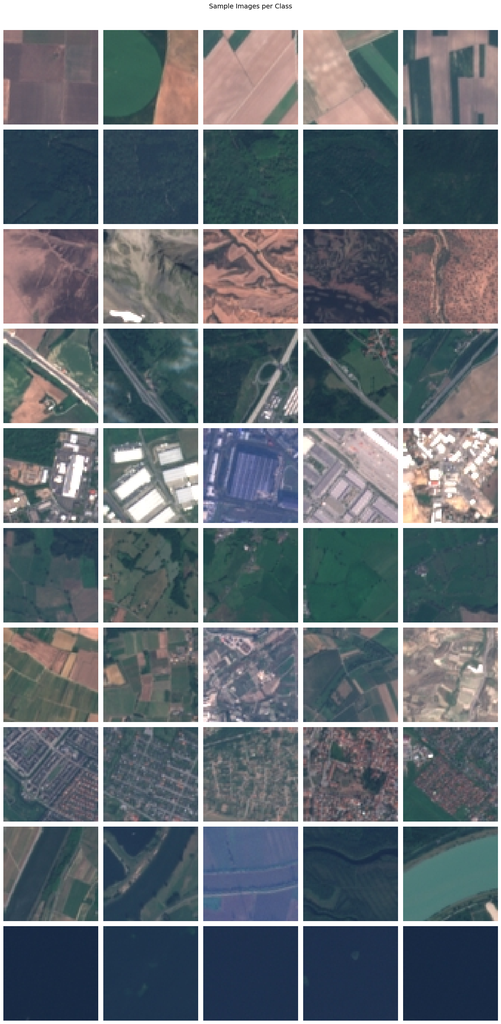

```python
# Sample images from each class
# Inverse normalization: reverses the ImageNet normalization for display
inv_normalize = transforms.Normalize(
    mean=[-m / s for m, s in zip(IMAGENET_MEAN, IMAGENET_STD)],
    std=[1.0 / s for s in IMAGENET_STD]
)

fig, axes = plt.subplots(len(class_names), 5, figsize=(15, 30))
samples_per_class = {}
for img, label in full_dataset:
    name = class_names[label]
    if name not in samples_per_class:
        samples_per_class[name] = []
    if len(samples_per_class[name]) < 5:
        samples_per_class[name].append(img)
    if len(samples_per_class) == len(class_names) and all(len(v) == 5 for v in samples_per_class.values()):
        break

for i, cls in enumerate(class_names):
    for j in range(5):
        axes[i, j].imshow(samples_per_class[cls][j])
        axes[i, j].axis("off")
        if j == 0:
            axes[i, j].set_ylabel(cls, fontsize=10, rotation=0, labelpad=60)
plt.suptitle("Sample Images per Class", y=1.01, fontsize=14)
plt.tight_layout()
plt.savefig(os.path.join(OUTPUT_DIR, "sample_images.png"), dpi=150, bbox_inches="tight")
plt.show()
```

## 4b. Augmentation Visualization

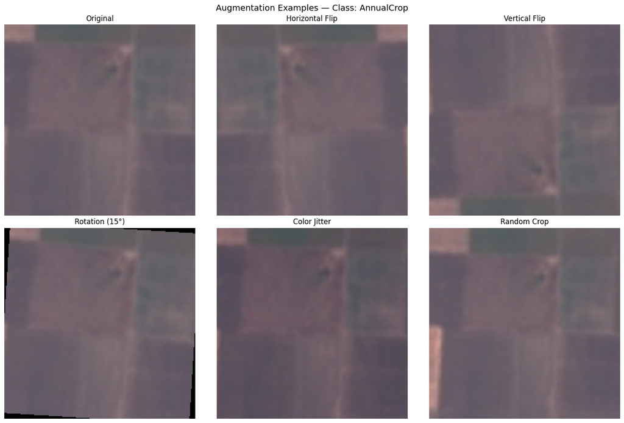

```
Saved augmentation_examples.png
```

```python
# Visualize each augmentation applied to a sample image
sample_img, sample_label = full_dataset[0]
sample_class = class_names[sample_label]

# Define individual augmentations for visualization
augmentation_examples = {
    "Original": transforms.Compose([transforms.Resize(256), transforms.CenterCrop(224)]),
    "Horizontal Flip": transforms.Compose([transforms.Resize(256), transforms.CenterCrop(224),
                                            transforms.RandomHorizontalFlip(p=1.0)]),
    "Vertical Flip": transforms.Compose([transforms.Resize(256), transforms.CenterCrop(224),
                                          transforms.RandomVerticalFlip(p=1.0)]),
    "Rotation (15°)": transforms.Compose([transforms.Resize(256), transforms.CenterCrop(224),
                                           transforms.RandomRotation(15)]),
    "Color Jitter": transforms.Compose([transforms.Resize(256), transforms.CenterCrop(224),
                                         transforms.ColorJitter(brightness=0.2, contrast=0.2,
                                                                saturation=0.1, hue=0.02)]),
    "Random Crop": transforms.Compose([transforms.Resize(256),
                                        transforms.RandomResizedCrop(224, scale=(0.8, 1.0))]),
}

fig, axes = plt.subplots(2, 3, figsize=(15, 10))
for idx, (name, transform) in enumerate(augmentation_examples.items()):
    row, col = idx // 3, idx % 3
    augmented = transform(sample_img)
    axes[row, col].imshow(augmented)
    axes[row, col].set_title(name, fontsize=12)
    axes[row, col].axis("off")

plt.suptitle(f"Augmentation Examples — Class: {sample_class}", fontsize=14)
plt.tight_layout()
plt.savefig(os.path.join(OUTPUT_DIR, "augmentation_examples.png"), dpi=150)
plt.show()
print("Saved augmentation_examples.png")
```

### Why These Augmentations?

Satellite images have unique properties different from natural photos — the camera (Sentinel-2) is always directly overhead, so:

| Augmentation | Why |
| --- | --- |
| **Horizontal flip** | A forest looks the same mirrored |
| **Vertical flip** | Satellite is overhead — north/south are arbitrary |
| **Random rotation (15°)** | Land patches can appear at any orientation |
| **Color jitter** | Atmospheric conditions change colors between captures |
| **RandomResizedCrop** | Simulates zoom level and position variation |

**Why vertical flip is important:** In natural photo datasets (ImageNet), vertical flips are wrong (an upside-down dog is not a dog). But satellite images are orientation-agnostic — a river or crop field looks valid from any angle.

## 5. Model Definition

```python
# --- Bottleneck Block ---
# The building block of ResNet50: 1x1 → 3x3 → 1x1 with skip connection
# Each block has 3 conv layers. ResNet50 uses 16 blocks total (3+4+6+3)

class Bottleneck(nn.Module):
    """ResNet50 bottleneck block: 1x1 → 3x3 → 1x1 with skip connection."""
    expansion = 4

    def __init__(self, in_channels, out_channels, stride=1, downsample=None):
        super().__init__()
        self.conv1 = nn.Conv2d(in_channels, out_channels, kernel_size=1, bias=False)
        self.bn1 = nn.BatchNorm2d(out_channels)
        self.conv2 = nn.Conv2d(out_channels, out_channels, kernel_size=3,
                               stride=stride, padding=1, bias=False)
        self.bn2 = nn.BatchNorm2d(out_channels)
        self.conv3 = nn.Conv2d(out_channels, out_channels * self.expansion,
                               kernel_size=1, bias=False)
        self.bn3 = nn.BatchNorm2d(out_channels * self.expansion)
        self.relu = nn.ReLU(inplace=True)
        self.downsample = downsample

    def forward(self, x):
        identity = x

        out = self.conv1(x)
        out = self.bn1(out)
        out = self.relu(out)

        out = self.conv2(out)
        out = self.bn2(out)
        out = self.relu(out)

        out = self.conv3(out)
        out = self.bn3(out)

        if self.downsample is not None:
            identity = self.downsample(x)

        out += identity
        out = self.relu(out)
        return out

print("Bottleneck block defined.")
```

```
Bottleneck block defined.
```

```python
# --- ResNet50 Network ---
# Stacks Bottleneck blocks: 3 + 4 + 6 + 3 = 16 blocks = 48 conv layers
# Plus stem (1 conv) + FC (1 linear) = 50 layers total

class ResNet50(nn.Module):
    """ResNet50 manually implemented from scratch."""

    def __init__(self, num_classes=10):
        super().__init__()

        # Stem: initial feature extraction
        self.conv1 = nn.Conv2d(3, 64, kernel_size=7, stride=2, padding=3, bias=False)
        self.bn1 = nn.BatchNorm2d(64)
        self.relu = nn.ReLU(inplace=True)
        self.maxpool = nn.MaxPool2d(kernel_size=3, stride=2, padding=1)

        # Residual layers
        self.layer1 = self._make_layer(64, 64, blocks=3, stride=1)
        self.layer2 = self._make_layer(256, 128, blocks=4, stride=2)
        self.layer3 = self._make_layer(512, 256, blocks=6, stride=2)
        self.layer4 = self._make_layer(1024, 512, blocks=3, stride=2)

        # Classifier
        self.avgpool = nn.AdaptiveAvgPool2d((1, 1))
        self.fc = nn.Linear(512 * Bottleneck.expansion, num_classes)

        # Weight initialization
        for m in self.modules():
            if isinstance(m, nn.Conv2d):
                nn.init.kaiming_normal_(m.weight, mode="fan_out", nonlinearity="relu")
            elif isinstance(m, nn.BatchNorm2d):
                nn.init.constant_(m.weight, 1)
                nn.init.constant_(m.bias, 0)

    def _make_layer(self, in_channels, out_channels, blocks, stride):
        downsample = None
        if stride != 1 or in_channels != out_channels * Bottleneck.expansion:
            downsample = nn.Sequential(
                nn.Conv2d(in_channels, out_channels * Bottleneck.expansion,
                          kernel_size=1, stride=stride, bias=False),
                nn.BatchNorm2d(out_channels * Bottleneck.expansion),
            )

        layers = [Bottleneck(in_channels, out_channels, stride, downsample)]
        for _ in range(1, blocks):
            layers.append(Bottleneck(out_channels * Bottleneck.expansion, out_channels))

        return nn.Sequential(*layers)

    def forward(self, x):
        x = self.conv1(x)
        x = self.bn1(x)
        x = self.relu(x)
        x = self.maxpool(x)

        x = self.layer1(x)
        x = self.layer2(x)
        x = self.layer3(x)
        x = self.layer4(x)

        x = self.avgpool(x)
        x = torch.flatten(x, 1)
        x = self.fc(x)
        return x

print("ResNet50 class defined.")
```

```
ResNet50 class defined.
```

```python
# Create model and count parameters
model = ResNet50(num_classes=NUM_CLASSES).to(DEVICE)

total_params = sum(p.numel() for p in model.parameters())
trainable_params = sum(p.numel() for p in model.parameters() if p.requires_grad)
print(f"Total parameters: {total_params:,}")
print(f"Trainable parameters: {trainable_params:,}")
```

```
Total parameters: 23,528,522
Trainable parameters: 23,528,522
```

## Architecture: ResNet50 — Why and How

> *"Deep Residual Learning for Image Recognition"* — He et al., 2015 (227,000+ citations) Winner of ILSVRC 2015 with **3.57% top-5 error** on ImageNet

### The Problem: Degradation

Adding more layers to a network should improve accuracy, but in practice, **deeper plain networks get *worse*** — not because of overfitting, but because deeper networks are harder to optimize. A 56-layer network has *higher training error* than a 20-layer network.

### The Solution: Skip Connections

Instead of learning a direct mapping H(x), ResNet learns a **residual**: F(x) = H(x) − x, and the output becomes **F(x) + x**.

```
Input x ────────────────────────────┐
  │                                  │
  ├─ Conv 1×1 (reduce)              │
  │  BatchNorm → ReLU               │
  ├─ Conv 3×3                       │
  │  BatchNorm → ReLU               │
  ├─ Conv 1×1 (expand)              │
  │  BatchNorm                      │
  │                                  │
  └────────────── + ←───────────────┘
                 │
              ReLU → Output
```

**Why it works:** If the optimal transformation is close to identity, the network just needs to push F(x) toward zero — much easier than learning identity from scratch. Skip connections also create "information highways" for gradient flow, preventing vanishing gradients in 50+ layer networks.

### Bottleneck Block Design (1×1 → 3×3 → 1×1)

Used in ResNet-50/101/152 (not in ResNet-18/34):

| Layer | Operation | Channels | Purpose |
| --- | --- | --- | --- |
| 1 | **1×1 Conv** | 64→64 | Reduce dimensions (bottleneck) |
| 2 | **3×3 Conv** | 64→64 | Extract spatial features |
| 3 | **1×1 Conv** | 64→256 | Expand back to full channels |

**Why bottleneck?** A single 3×3 conv from 256→256 channels costs **590K parameters**. The bottleneck path (256→64→64→256) costs only **70K parameters** — **8.4× fewer** while maintaining representational power.

### ResNet50 Layer Structure

[output not shown]

**Total: ~23.5M parameters** | **3.8 billion FLOPs** per image

### Batch Normalization

> *"Batch Normalization: Accelerating Deep Network Training"* — Ioffe & Szegedy, 2015

**Problem:** As training progresses, each layer's input distribution shifts (internal covariate shift), requiring careful initialization and small learning rates.

**Solution:** Normalize each mini-batch: `x̂ = (x − μ_batch) / √(σ² + ε)`, then learn scale γ and shift β.

Applied after every convolution, before ReLU in our ResNet50:

```
Conv2d → BatchNorm2d → ReLU → Conv2d → BatchNorm2d → ReLU → ...
```

**Why it matters:**

- Enables **14× faster training** (from the paper)
- Allows **10× higher learning rates** without divergence
- Provides regularization (reduces need for Dropout)
- Critical for training 50+ layers from scratch

**Initialization in our model:** BN weights = 1, BN biases = 0 (standard practice)

### Weight Initialization: Kaiming (He) Init

> *"Delving Deep into Rectifiers"* — He et al., 2015

**Why not Xavier/Glorot?** Xavier init assumes linear activations, but ReLU zeros out half the values — requiring a factor-of-2 correction:

| Init | Formula | For |
| --- | --- | --- |
| Xavier | `Var(W) = 1/n_fan_in` | Linear/tanh |
| **Kaiming** | **`Var(W) = 2/n_fan_in`** | **ReLU** |

The extra factor of 2 compensates for the variance lost when ReLU kills half the activations. Without this, signal vanishes through 50+ layers — making training from scratch impossible.

**In our model:** `nn.init.kaiming_normal_(m.weight, mode="fan_out", nonlinearity="relu")` for all Conv2d layers.

## 6. Optimizer, Scheduler, and Loss

```python
# Class-weighted loss — minority classes get higher penalty for mistakes
class_weights_tensor = torch.tensor(class_weights, dtype=torch.float32).to(DEVICE)
criterion = nn.CrossEntropyLoss(weight=class_weights_tensor)

optimizer = optim.AdamW(model.parameters(), lr=LEARNING_RATE, weight_decay=WEIGHT_DECAY)
scheduler = optim.lr_scheduler.CosineAnnealingLR(optimizer, T_max=NUM_EPOCHS, eta_min=1e-6)
scaler = torch.amp.GradScaler("cuda", enabled=USE_AMP)

print(f"Loss: CrossEntropyLoss (weighted for class imbalance)")
print(f"Optimizer: AdamW (lr={LEARNING_RATE}, weight_decay={WEIGHT_DECAY})")
print(f"Scheduler: CosineAnnealingLR (T_max={NUM_EPOCHS})")
print(f"Mixed precision: {USE_AMP}")
```

```
Loss: CrossEntropyLoss (weighted for class imbalance)
Optimizer: AdamW (lr=0.0003, weight_decay=0.0001)
Scheduler: CosineAnnealingLR (T_max=100)
Mixed precision: True
```

### Optimizer: Why AdamW, Not Adam or SGD?

> *"Decoupled Weight Decay Regularization"* — Loshchilov & Hutter, 2019

**The problem with Adam + L2:** In Adam, the L2 penalty gets scaled by adaptive learning rates — making regularization inconsistent and ineffective.

**AdamW fix:** Decouples weight decay from the gradient step:

```
# Standard Adam + L2:
loss = loss_fn(output, target) + λ * ||w||²    # regularization gets scaled by Adam

# AdamW:
w = w - lr * wd * w    # weight decay applied directly, independent of Adam
w = w - lr * Adam(grad) # gradient step separate
```

**Result:** Weight decay and learning rate become independent hyperparameters — easier to tune and better generalization.

**Our choice:** AdamW with lr=3e-4, weight_decay=1e-4

### Learning Rate Schedule: Cosine Annealing

Smoothly decreases the learning rate from 3e-4 → 1e-6 following a cosine curve:

```
lr(t) = lr_min + 0.5 * (lr_max - lr_min) * (1 + cos(πt / T_max))
```

**Why not StepLR?** Step drops cause sudden jumps that destabilize training. Cosine provides smooth, continuous decay — the model gradually shifts from exploration (high lr) to refinement (low lr).

**Combined with early stopping (patience=8):** The scheduler handles the full 100-epoch plan, while early stopping prevents overfitting if the model converges early.

## 7. Training Loop

```python
history = {"train_loss": [], "train_acc": [], "val_loss": [], "val_acc": [], "lr": []}
best_val_acc = -1.0
best_model_wts = None
patience_counter = 0

print("Starting training...\n")

for epoch in range(NUM_EPOCHS):
    start_time = time.time()

    # --- Training ---
    model.train()
    running_loss, running_corrects, total = 0.0, 0, 0

    for inputs, labels in tqdm(train_loader, desc=f"Epoch {epoch+1}/{NUM_EPOCHS}", leave=False):
        inputs, labels = inputs.to(DEVICE), labels.to(DEVICE)

        optimizer.zero_grad()

        with torch.amp.autocast("cuda", enabled=USE_AMP):
            outputs = model(inputs)
            loss = criterion(outputs, labels)

        scaler.scale(loss).backward()
        scaler.step(optimizer)
        scaler.update()

        running_loss += loss.item() * inputs.size(0)
        _, preds = torch.max(outputs, 1)
        running_corrects += (preds == labels).sum().item()
        total += labels.size(0)

    train_loss = running_loss / total
    train_acc = running_corrects / total

    # --- Validation ---
    model.eval()
    val_loss, val_corrects, val_total = 0.0, 0, 0

    with torch.no_grad():
        for inputs, labels in val_loader:
            inputs, labels = inputs.to(DEVICE), labels.to(DEVICE)

            with torch.amp.autocast("cuda", enabled=USE_AMP):
                outputs = model(inputs)
                loss = criterion(outputs, labels)

            val_loss += loss.item() * inputs.size(0)
            _, preds = torch.max(outputs, 1)
            val_corrects += (preds == labels).sum().item()
            val_total += labels.size(0)

    val_loss = val_loss / val_total
    val_acc = val_corrects / val_total
    current_lr = scheduler.get_last_lr()[0]
    scheduler.step()

    elapsed = time.time() - start_time

    # --- Record history ---
    history["train_loss"].append(train_loss)
    history["train_acc"].append(train_acc)
    history["val_loss"].append(val_loss)
    history["val_acc"].append(val_acc)
    history["lr"].append(current_lr)

    print(f"Epoch [{epoch+1}/{NUM_EPOCHS}] {elapsed:.0f}s | "
          f"Train Loss: {train_loss:.4f} Acc: {train_acc:.4f} | "
          f"Val Loss: {val_loss:.4f} Acc: {val_acc:.4f} | "
          f"LR: {current_lr:.6f}")

    # --- Checkpoint ---
    if val_acc > best_val_acc:
        best_val_acc = val_acc
        best_model_wts = copy.deepcopy(model.state_dict())
        torch.save({
            "epoch": epoch,
            "model_state_dict": model.state_dict(),
            "optimizer_state_dict": optimizer.state_dict(),
            "best_val_acc": best_val_acc,
            "class_names": class_names,
        }, os.path.join(OUTPUT_DIR, "best_resnet50_eurosat.pth"))
        patience_counter = 0
        print(f"  -> New best model saved (val_acc: {val_acc:.4f})")
    else:
        patience_counter += 1
        if patience_counter >= PATIENCE:
            print(f"\nEarly stopping at epoch {epoch+1}")
            break

print(f"\nBest validation accuracy: {best_val_acc:.4f}")
```

```
Starting training...
```

```
Epoch [1/100] 146s | Train Loss: 1.2543 Acc: 0.5581 | Val Loss: 1.0867 Acc: 0.6200 | LR: 0.000300
  -> New best model saved (val_acc: 0.6200)
```

```
Epoch [2/100] 119s | Train Loss: 0.8605 Acc: 0.7033 | Val Loss: 1.2993 Acc: 0.6301 | LR: 0.000300
  -> New best model saved (val_acc: 0.6301)
```

```
Epoch [3/100] 117s | Train Loss: 0.6564 Acc: 0.7792 | Val Loss: 1.3508 Acc: 0.6556 | LR: 0.000300
  -> New best model saved (val_acc: 0.6556)
```

```
Epoch [4/100] 119s | Train Loss: 0.5293 Acc: 0.8197 | Val Loss: 1.4918 Acc: 0.6736 | LR: 0.000299
  -> New best model saved (val_acc: 0.6736)
```

```
Epoch [5/100] 118s | Train Loss: 0.4521 Acc: 0.8450 | Val Loss: 1.3414 Acc: 0.7316 | LR: 0.000299
  -> New best model saved (val_acc: 0.7316)
```

```
Epoch [6/100] 120s | Train Loss: 0.3768 Acc: 0.8725 | Val Loss: 0.3511 Acc: 0.8891 | LR: 0.000298
  -> New best model saved (val_acc: 0.8891)
```

```
Epoch [7/100] 118s | Train Loss: 0.3319 Acc: 0.8903 | Val Loss: 0.3201 Acc: 0.8914 | LR: 0.000297
  -> New best model saved (val_acc: 0.8914)
```

```
Epoch [8/100] 119s | Train Loss: 0.3127 Acc: 0.8940 | Val Loss: 0.2797 Acc: 0.9047 | LR: 0.000296
  -> New best model saved (val_acc: 0.9047)
```

```
Epoch [9/100] 117s | Train Loss: 0.2821 Acc: 0.9045 | Val Loss: 0.2114 Acc: 0.9341 | LR: 0.000295
  -> New best model saved (val_acc: 0.9341)
```

```
Epoch [10/100] 119s | Train Loss: 0.2648 Acc: 0.9092 | Val Loss: 0.2346 Acc: 0.9178 | LR: 0.000294
```

```
Epoch [11/100] 118s | Train Loss: 0.2378 Acc: 0.9195 | Val Loss: 0.2556 Acc: 0.9163 | LR: 0.000293
```

```
Epoch [12/100] 118s | Train Loss: 0.2276 Acc: 0.9216 | Val Loss: 0.3672 Acc: 0.8805 | LR: 0.000291
```

```
Epoch [13/100] 119s | Train Loss: 0.2239 Acc: 0.9240 | Val Loss: 0.2155 Acc: 0.9249 | LR: 0.000290
```

```
Epoch [14/100] 117s | Train Loss: 0.2071 Acc: 0.9294 | Val Loss: 0.1754 Acc: 0.9425 | LR: 0.000288
  -> New best model saved (val_acc: 0.9425)
```

```
Epoch [15/100] 118s | Train Loss: 0.1918 Acc: 0.9330 | Val Loss: 0.2131 Acc: 0.9291 | LR: 0.000286
```

```
Epoch [16/100] 117s | Train Loss: 0.1936 Acc: 0.9326 | Val Loss: 0.2036 Acc: 0.9252 | LR: 0.000284
```

```
Epoch [17/100] 120s | Train Loss: 0.1845 Acc: 0.9372 | Val Loss: 0.1622 Acc: 0.9437 | LR: 0.000282
  -> New best model saved (val_acc: 0.9437)
```

```
Epoch [18/100] 120s | Train Loss: 0.1804 Acc: 0.9388 | Val Loss: 0.1440 Acc: 0.9499 | LR: 0.000279
  -> New best model saved (val_acc: 0.9499)
```

```
Epoch [19/100] 120s | Train Loss: 0.1687 Acc: 0.9406 | Val Loss: 0.2852 Acc: 0.8891 | LR: 0.000277
```

```
Epoch [20/100] 120s | Train Loss: 0.1686 Acc: 0.9426 | Val Loss: 0.1519 Acc: 0.9472 | LR: 0.000274
```

```
Epoch [21/100] 121s | Train Loss: 0.1562 Acc: 0.9461 | Val Loss: 0.1564 Acc: 0.9499 | LR: 0.000271
```

```
Epoch [22/100] 123s | Train Loss: 0.1584 Acc: 0.9456 | Val Loss: 0.1732 Acc: 0.9457 | LR: 0.000269
```

```
Epoch [23/100] 119s | Train Loss: 0.1471 Acc: 0.9484 | Val Loss: 0.1069 Acc: 0.9637 | LR: 0.000266
  -> New best model saved (val_acc: 0.9637)
```

```
Epoch [24/100] 121s | Train Loss: 0.1386 Acc: 0.9513 | Val Loss: 0.1223 Acc: 0.9590 | LR: 0.000263
```

```
Epoch [25/100] 118s | Train Loss: 0.1421 Acc: 0.9524 | Val Loss: 0.1563 Acc: 0.9481 | LR: 0.000259
```

```
Epoch [26/100] 120s | Train Loss: 0.1401 Acc: 0.9524 | Val Loss: 0.1456 Acc: 0.9501 | LR: 0.000256
```

```
Epoch [27/100] 123s | Train Loss: 0.1311 Acc: 0.9545 | Val Loss: 0.1240 Acc: 0.9580 | LR: 0.000253
```

```
Epoch [28/100] 121s | Train Loss: 0.1293 Acc: 0.9535 | Val Loss: 0.1356 Acc: 0.9551 | LR: 0.000249
```

```
Epoch [29/100] 123s | Train Loss: 0.1344 Acc: 0.9525 | Val Loss: 0.1140 Acc: 0.9600 | LR: 0.000246
```

```
Epoch [30/100] 119s | Train Loss: 0.1239 Acc: 0.9561 | Val Loss: 0.1126 Acc: 0.9620 | LR: 0.000242
```

```
Epoch [31/100] 120s | Train Loss: 0.1210 Acc: 0.9574 | Val Loss: 0.0808 Acc: 0.9728 | LR: 0.000238
  -> New best model saved (val_acc: 0.9728)
```

```
Epoch [32/100] 118s | Train Loss: 0.1112 Acc: 0.9613 | Val Loss: 0.0995 Acc: 0.9652 | LR: 0.000235
```

```
Epoch [33/100] 119s | Train Loss: 0.1146 Acc: 0.9585 | Val Loss: 0.1028 Acc: 0.9662 | LR: 0.000231
```

```
Epoch [34/100] 117s | Train Loss: 0.1061 Acc: 0.9628 | Val Loss: 0.0998 Acc: 0.9642 | LR: 0.000227
```

```
Epoch [35/100] 117s | Train Loss: 0.1073 Acc: 0.9616 | Val Loss: 0.1136 Acc: 0.9620 | LR: 0.000223
```

[output not shown]

```
Epoch [38/100] 121s | Train Loss: 0.0981 Acc: 0.9654 | Val Loss: 0.0908 Acc: 0.9701 | LR: 0.000210
```

```
Epoch [39/100] 120s | Train Loss: 0.0998 Acc: 0.9650 | Val Loss: 0.1342 Acc: 0.9563 | LR: 0.000206

Early stopping at epoch 39

Best validation accuracy: 0.9728
```

## 8. Training Curves

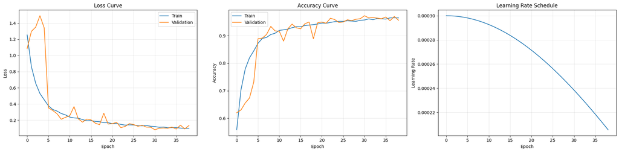

```python
fig, axes = plt.subplots(1, 3, figsize=(20, 5))

# Loss
axes[0].plot(history["train_loss"], label="Train")
axes[0].plot(history["val_loss"], label="Validation")
axes[0].set_xlabel("Epoch")
axes[0].set_ylabel("Loss")
axes[0].set_title("Loss Curve")
axes[0].legend()
axes[0].grid(True, alpha=0.3)

# Accuracy
axes[1].plot(history["train_acc"], label="Train")
axes[1].plot(history["val_acc"], label="Validation")
axes[1].set_xlabel("Epoch")
axes[1].set_ylabel("Accuracy")
axes[1].set_title("Accuracy Curve")
axes[1].legend()
axes[1].grid(True, alpha=0.3)

# Learning rate
axes[2].plot(history["lr"])
axes[2].set_xlabel("Epoch")
axes[2].set_ylabel("Learning Rate")
axes[2].set_title("Learning Rate Schedule")
axes[2].grid(True, alpha=0.3)

plt.tight_layout()
plt.savefig(os.path.join(OUTPUT_DIR, "training_curves.png"), dpi=150)
plt.show()
```

## 9. Test Evaluation

```python
# Load best model
if best_model_wts is not None:
    model.load_state_dict(best_model_wts)
model.eval()

all_preds, all_labels = [], []

with torch.no_grad():
    for inputs, labels in tqdm(test_loader, desc="Testing"):
        inputs = inputs.to(DEVICE)

        with torch.amp.autocast("cuda", enabled=USE_AMP):
            outputs = model(inputs)

        _, preds = torch.max(outputs, 1)
        all_preds.extend(preds.cpu().numpy())
        all_labels.extend(labels.numpy())

# Metrics
test_acc = accuracy_score(all_labels, all_preds)
macro_f1 = f1_score(all_labels, all_preds, average="macro")
weighted_f1 = f1_score(all_labels, all_preds, average="weighted")

print(f"Test Accuracy:  {test_acc:.4f}")
print(f"Macro F1:       {macro_f1:.4f}")
print(f"Weighted F1:    {weighted_f1:.4f}")
print()
print(classification_report(all_labels, all_preds, target_names=class_names, digits=4))
```

```
Test Accuracy:  0.9714
Macro F1:       0.9708
Weighted F1:    0.9713

                      precision    recall  f1-score   support

          AnnualCrop     0.9618    0.9749    0.9683       439
              Forest     0.9823    0.9933    0.9878       447
HerbaceousVegetation     0.9379    0.9702    0.9538       436
             Highway     0.9530    0.9759    0.9643       374
          Industrial     0.9814    0.9711    0.9762       380
             Pasture     0.9775    0.9739    0.9757       268
       PermanentCrop     0.9590    0.9188    0.9385       382
         Residential     0.9794    0.9930    0.9861       430
               River     0.9851    0.9476    0.9660       420
             SeaLake     0.9957    0.9873    0.9915       474

            accuracy                         0.9714      4050
           macro avg     0.9713    0.9706    0.9708      4050
        weighted avg     0.9716    0.9714    0.9713      4050
```

## 10. Confusion Matrix

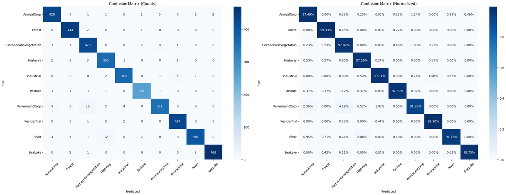

```python
cm = confusion_matrix(all_labels, all_preds)
cm_norm = cm.astype("float") / cm.sum(axis=1)[:, np.newaxis]

fig, axes = plt.subplots(1, 2, figsize=(24, 9))

# Raw counts
sns.heatmap(cm, annot=True, fmt="d", cmap="Blues",
            xticklabels=class_names, yticklabels=class_names, ax=axes[0])
axes[0].set_xlabel("Predicted")
axes[0].set_ylabel("True")
axes[0].set_title("Confusion Matrix (Counts)")
axes[0].tick_params(axis="x", rotation=45)
axes[0].tick_params(axis="y", rotation=0)

# Normalized
sns.heatmap(cm_norm, annot=True, fmt=".2%", cmap="Blues",
            xticklabels=class_names, yticklabels=class_names, ax=axes[1])
axes[1].set_xlabel("Predicted")
axes[1].set_ylabel("True")
axes[1].set_title("Confusion Matrix (Normalized)")
axes[1].tick_params(axis="x", rotation=45)
axes[1].tick_params(axis="y", rotation=0)

plt.tight_layout()
plt.savefig(os.path.join(OUTPUT_DIR, "confusion_matrix.png"), dpi=150)
plt.show()
```

## 11. Per-Class Accuracy

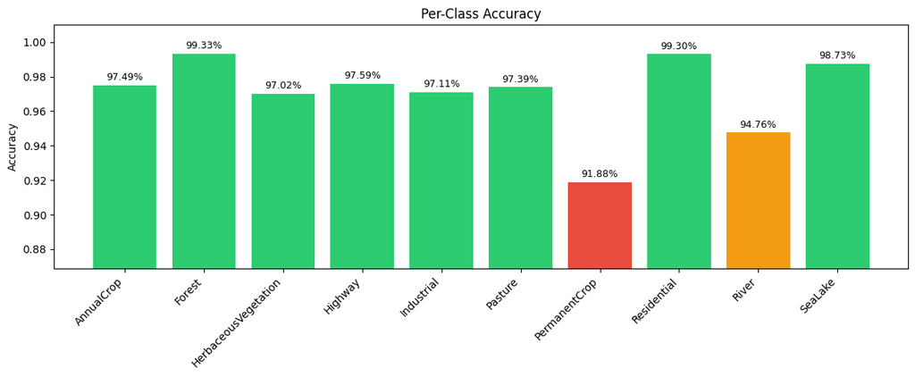

```python
per_class_acc = cm.diagonal() / cm.sum(axis=1)

fig, ax = plt.subplots(figsize=(12, 5))
colors = ["#2ecc71" if acc >= 0.97 else "#e74c3c" if acc < 0.93 else "#f39c12" for acc in per_class_acc]
bars = ax.bar(class_names, per_class_acc, color=colors)
ax.set_ylim(min(per_class_acc) - 0.05, 1.01)
ax.set_ylabel("Accuracy")
ax.set_title("Per-Class Accuracy")
plt.xticks(rotation=45, ha="right")

for bar, acc in zip(bars, per_class_acc):
    ax.text(bar.get_x() + bar.get_width() / 2, bar.get_height() + 0.003,
            f"{acc:.2%}", ha="center", fontsize=9)

plt.tight_layout()
plt.savefig(os.path.join(OUTPUT_DIR, "per_class_accuracy.png"), dpi=150)
plt.show()
```

## 12. Sample Predictions

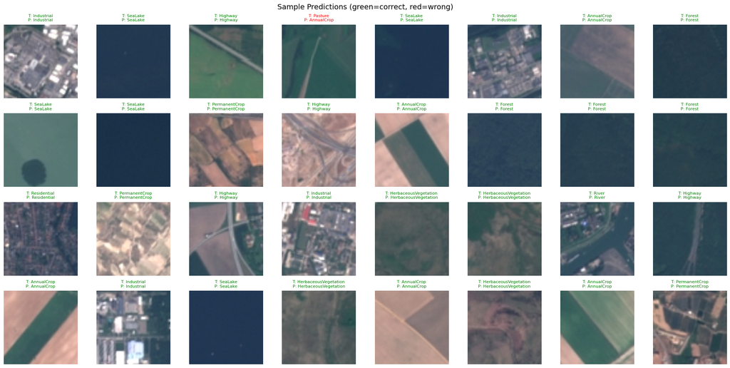

```python
# Show test images with predictions
model.eval()
images_shown, num_rows, num_cols = 0, 4, 8

fig, axes = plt.subplots(num_rows, num_cols, figsize=(20, 10))

with torch.no_grad():
    for inputs, labels in test_loader:
        inputs_gpu = inputs.to(DEVICE)
        with torch.amp.autocast("cuda", enabled=USE_AMP):
            outputs = model(inputs_gpu)
        _, preds = torch.max(outputs, 1)

        for i in range(inputs.size(0)):
            if images_shown >= num_rows * num_cols:
                break

            row, col = images_shown // num_cols, images_shown % num_cols
            img = inv_normalize(inputs[i]).permute(1, 2, 0).numpy()
            img = np.clip(img, 0, 1)

            true_name = class_names[labels[i]]
            pred_name = class_names[preds[i].item()]
            correct = true_name == pred_name

            axes[row, col].imshow(img)
            axes[row, col].set_title(
                f"T: {true_name}\nP: {pred_name}",
                fontsize=8, color="green" if correct else "red"
            )
            axes[row, col].axis("off")
            images_shown += 1

        if images_shown >= num_rows * num_cols:
            break

plt.suptitle("Sample Predictions (green=correct, red=wrong)", fontsize=14)
plt.tight_layout()
plt.savefig(os.path.join(OUTPUT_DIR, "sample_predictions.png"), dpi=150)
plt.show()
```

[output not shown]

## Results Summary

[output not shown]

## Live Demo → Switch to Streamlit